### **Диагностика выбросов (price)**

#### **Анализ price**

*Расчет межквартильной разницы СВ:*

```r
paste('Межквартильный размах: IQR = Q3 - Q1 = ', round(IQR(df$price), 3))
```

```
## [1] "Межквартильный размах: IQR = Q3 - Q1 =  8715"
```

*Найдем значения, выходящие за пределы 1,5IQR:*

```r
out_of_1.5IQR10 <- boxplot.stats(df$price)$out
out_of_1.5IQR10
```

```
##  [1] 30760.0 41315.0 36880.0 32250.0 35550.0 36000.0 31600.0 34184.0 35056.0
## [10] 40960.0 45400.0 32528.0 34028.0 37028.0 31400.5
```

Получаем 15 выбросов (их значения приведены выше).

*Применим правило 3IQR:*

```r
out_of_3IQR10 <- boxplot.stats(df$price, coef = 3)$out
out_of_3IQR10
```

```
## [1] 45400
```

По правилу 3IQR один выброс, принимающий значение 45400$.

*Правило 3-х сигм:*

```r
paste('3σ = ', round(3*sd(df$price), 3))
```

```
## [1] "3σ =  23966.557"
```

```r
paste('Среднее: ', round(mean(df$price), 3))
```

```
## [1] "Среднее:  13276.711"
```

$$P(|x-13276,711| < 23966,557)= 0,9973$$

*Построим ящичковую диаграмму для данной СВ:*

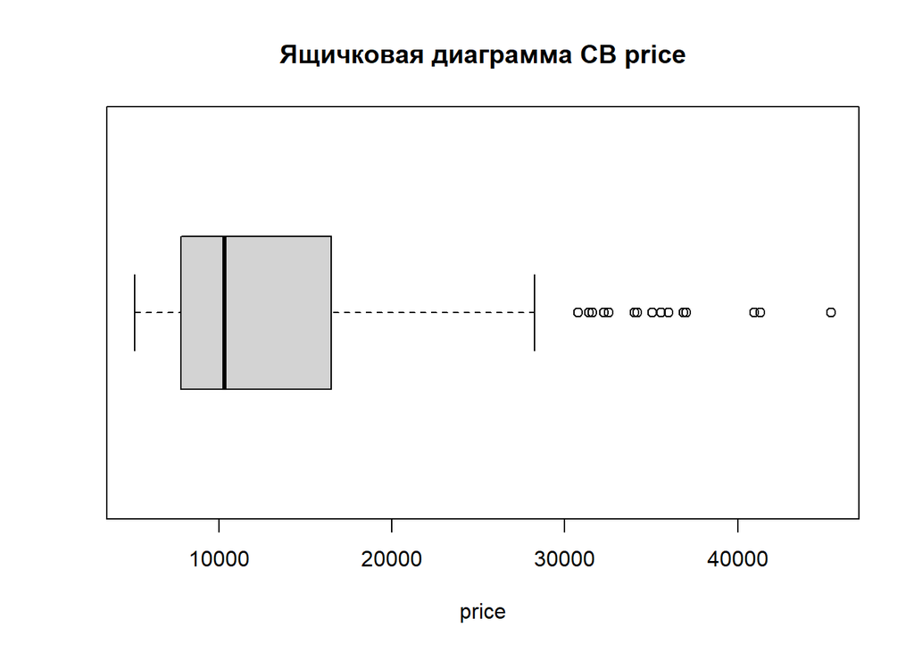

```r
boxplot(df$price, horizontal = TRUE, xlab = 'price', main = 'Ящичковая диаграмма СВ price')
```

На графике мы видим много выбросов, выходящие за пределы правила 1,5IQR. Их значения мы нашли выше. Медиана равна 10295 и находится ближе к значению первого квартиля (смещена влево в прямоугольнике). Первый квартиль принимает значение около 8000 , третий - около 17000.

*Проведем тест Граббса для данной СВ:*

```r
grubbs.test(df$price)
```

```
##
##  Grubbs test for one outlier
##
## data:  df$price
## G = 4.02101, U = 0.92035, p-value = 0.004241
## alternative hypothesis: highest value 45400 is an outlier
```

```r
grubbs.test(df$price, opposite = TRUE)
```

```
##
##  Grubbs test for one outlier
##
## data:  df$price
## G = 1.02126, U = 0.99486, p-value = 1
## alternative hypothesis: lowest value 5118 is an outlier
```